# Introduction

In part A, we had analysed the loan data with the aim to understand and summarise the different behaviours or attributes between customers who paid back their loan and customers who did not. This time around, we take a more advanced approach, we use the historical data to design a process which predicts the likelihood of a new customer not paying back their loan. In other to achieve this set objective, we shall be using some machine learning approaches available in literature. This part of the work is primarily aimed at building a predictive model.

In the end, we shall compare the different machine learning algorithms used using different accuuracy metrics and choose the one which performs best as our choice model.

We proceeded with the task here by using the already clean data from part A.

Data => cleaned loan dataset from part A

# Data Preprocessing

We take 'Charged Off' as our positive class since we are interested in a customer not paying back.

We make a correlation plot and possibly remove highly correlating ($r \geq \pm9$ ) columns. Where $r$ is the correlation coefficient.

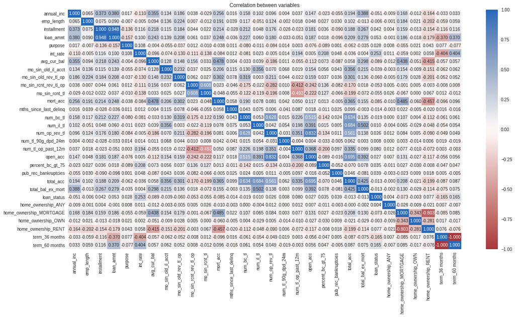

From the above correlation heatmap, we drop `term_36 months` and `loan_amnt` because of their high correlation to `term_60 months` and `installment` respectively.

## Standard Scaling, Robust Scaling & Train-Test Split

The box plot below shows that our dataset is still filled with an overwhelming amount of outliers and standard scaling did not help in this regard. Now, we use Robust Scaling for these columns.

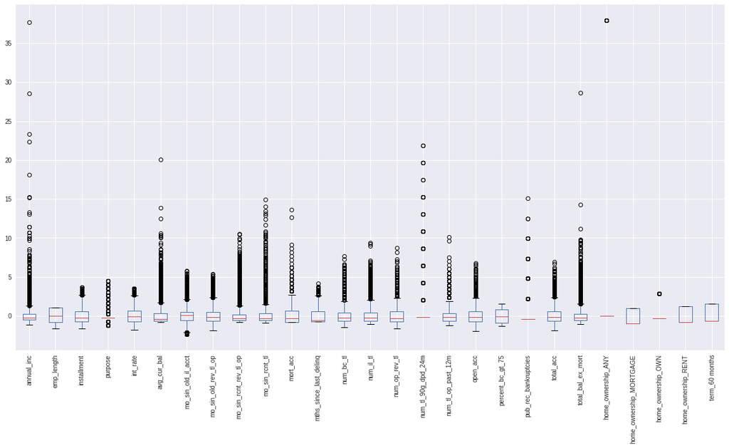

## Preprocessed Dataset Overview

```
<class 'pandas.core.frame.DataFrame'>
RangeIndex: 15863 entries, 0 to 15862
Data columns (total 27 columns):
 #   Column                   Non-Null Count  Dtype
---  ------                   --------------  -----
 0   annual_inc               15863 non-null  float64
 1   emp_length               15863 non-null  float64
 2   installment              15863 non-null  float64
 3   purpose                  15863 non-null  float64
 4   int_rate                 15863 non-null  float64
 5   avg_cur_bal              15863 non-null  float64
 6   mo_sin_old_il_acct       15863 non-null  float64
 7   mo_sin_old_rev_tl_op     15863 non-null  float64
 8   mo_sin_rcnt_rev_tl_op    15863 non-null  float64
 9   mo_sin_rcnt_tl           15863 non-null  float64
```

[output cut: 19 more lines]

Updated dataset has 5 new columns with some other variables in the previous data being removed.

# Models

## A. Isolation Forest

```
array([[  521,  1761],
       [ 2826, 10755]])
```

We have that to be the confusion matrix of the isolation forest model, we understand it better with the classification report.

```
              precision    recall  f1-score   support

          -1       0.16      0.23      0.19      2282
           1       0.86      0.79      0.82     13581

    accuracy                           0.71     15863
   macro avg       0.51      0.51      0.50     15863
weighted avg       0.76      0.71      0.73     15863
```

We can see that the precision for '-1' our Charged off class is really low. As a result, this model is not ideal.

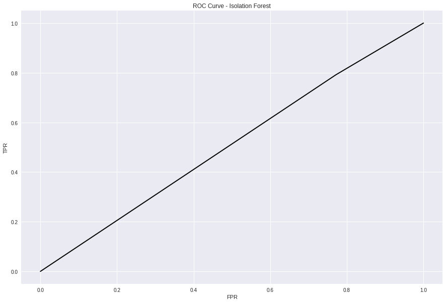

The curve also shows the model's inability to differentiate the classes.

```
Accuracy in Detecting Fully Paid Cases: 0.8514376996805112
Accuracy in Detecting Charged Off Cases: 0.155661786674634
```

With the accuracy shown, we are dissatified with this model.

## B. One Class SVM

```
array([[1854, 6259],
       [1493, 6257]])
```

This is the confusion matrix for the OneClass SVM model.

```
              precision    recall  f1-score   support

          -1       0.55      0.23      0.32      8113
           1       0.50      0.81      0.62      7750

    accuracy                           0.51     15863
   macro avg       0.53      0.52      0.47     15863
weighted avg       0.53      0.51      0.47     15863
```

```
Accuracy in Detecting Fully Paid Cases: 0.4972044728434505
Accuracy in Detecting Charged Off Cases: 0.5539288915446668
```

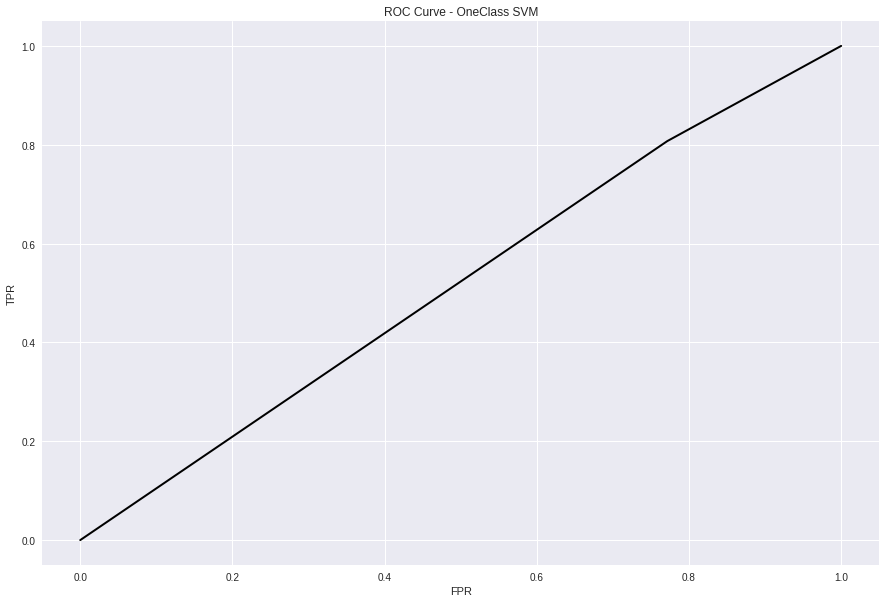

## D. KNN

The confusion matrix of the KNN looks very promising as it does well to identity 139 Charged off cases.

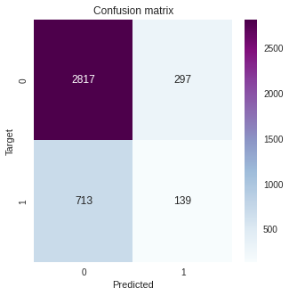

The classification report also does well to attest to this even though there is a slight trade off with the one class SVM.

```
              precision    recall  f1-score   support

           0       0.80      0.90      0.85      3114
           1       0.32      0.16      0.22       852

    accuracy                           0.75      3966
   macro avg       0.56      0.53      0.53      3966
weighted avg       0.70      0.75      0.71      3966
```

## E. Logistic Regression

The confusion matrix of the Logistic Regression algorithm shows good promise as well.

```
array([[3057,   57],
       [ 786,   66]])
```

```
              precision    recall  f1-score   support

           0       0.80      0.98      0.88      3114
           1       0.54      0.08      0.14       852

    accuracy                           0.79      3966
   macro avg       0.67      0.53      0.51      3966
weighted avg       0.74      0.79      0.72      3966
```

Finally, we look at the weights of each variable in the logistic regression as shown in the next slide.

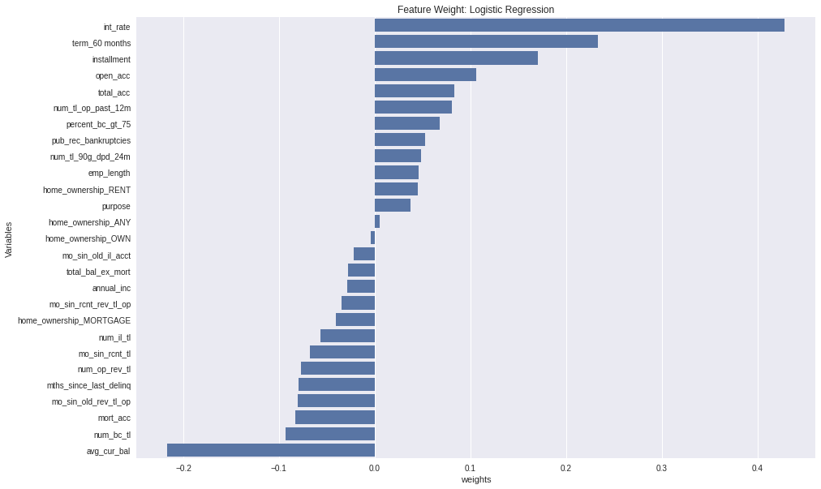

From the above, interest rate, loan tenor of 60 months, and installment are key to predicting a customer defaulter. Also, on the negative scale, the average current balance is a key feature as well.

## Prediction Probabilities: KNN vs LR

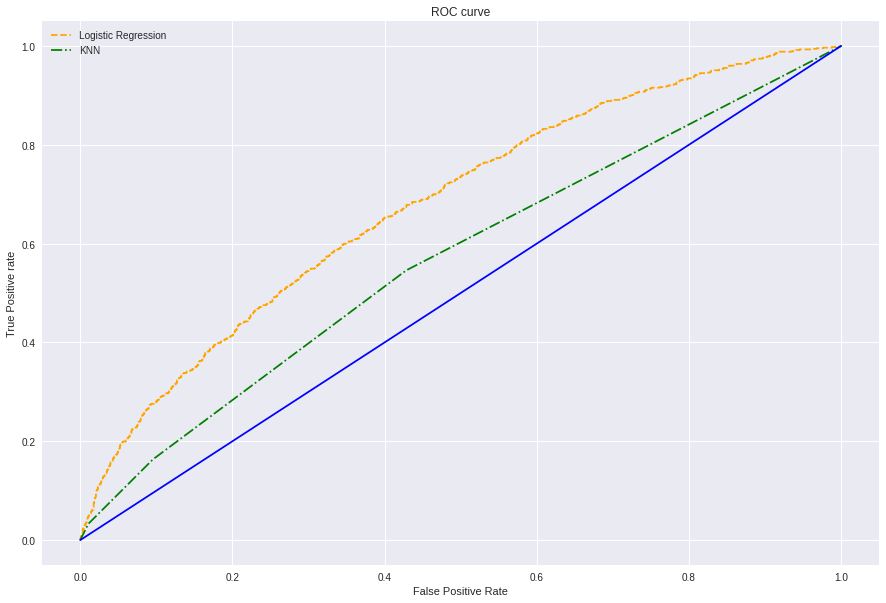